# R Notebook

1. how to interpret the Residuals vs Leverage diagnostic plot produced by plotting the lm() model object

Looking at the sensitivity of the fitted predicted y in a change in actual y Cook’s distance : measures the effect of deleting a point on the combined parameter vector (dotted red line). The point outsde the dotted red line have a high influence.

2. Project Management Analysis

Loading library

```r
library(tidyverse)
```

```r
my_theme <- function(){
  theme_dark() +
  theme(
    title = element_text(size = 12, face = "bold"),
    axis.title = element_text(size = 8, face = "bold"),
    panel.grid = element_line(colour = "grey67")
  )
}
```

Load the data into a dataframe project

```r
project <- read_csv("~/de1_classnotes/week_07/day_2/5_regression_homework/project_management.csv")
```

```r
dim(project)
```

```
[1] 50  3
```

```r
names(project)
```

```
[1] "X1"               "estimated_length" "actual_length"
```

```r
head(project)
```

| X1 | estimated_length | actual_length |
| --- | --- | --- |
| 1 | 12 | 17 |
| 2 | 16 | 22 |
| 3 | 16 | 23 |
| 4 | 18 | 25 |
| 5 | 22 | 39 |
| 6 | 19 | 24 |

Plot the data

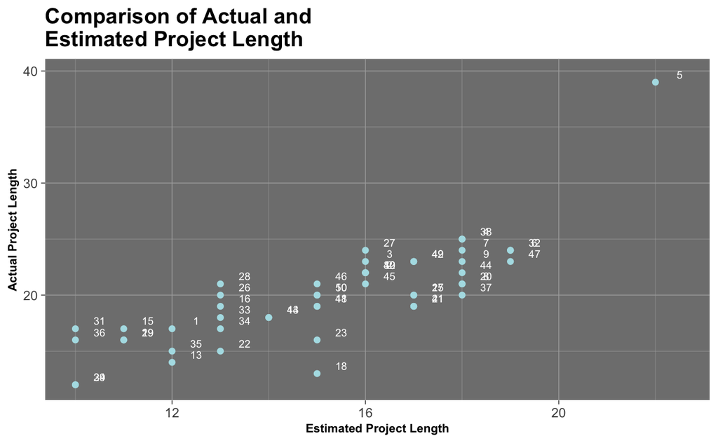

```r
ggplot(project) +
  aes(x = estimated_length, y = actual_length) +
  geom_point(colour = "powderblue") +
  labs(
    x = "Estimated Project Length",
    y = "Actual Project Length",
    title = "Comparison of Actual and\nEstimated Project Length"
  ) +
  geom_text(aes(label = X1), nudge_x = 0.5,
            nudge_y = 0.7, size = 2.5, colour = "white") +
  my_theme()
```

potential outliers: 5 : influential 18: not influential

Regress actual_length on estimated_length and confirm your visual assessment of which points are ‘influential’ or ‘non-influential’ outliers based on the “Cook’s distance” lines in the Residuals vs Leverage diagnostic plot.

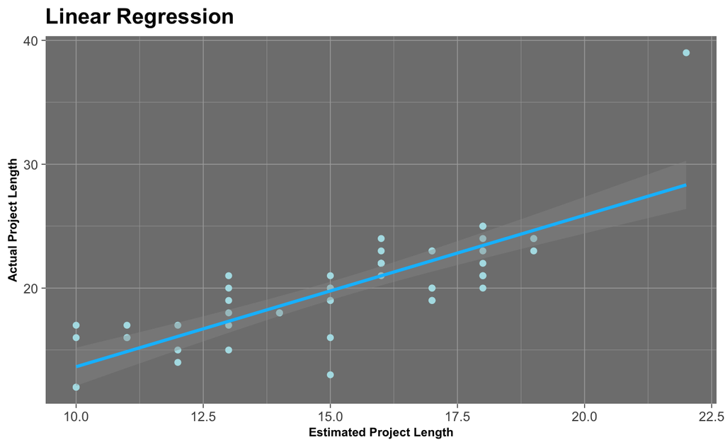

```r
ggplot(project) +
  aes(x = estimated_length, y = actual_length) +
  geom_point(colour = "powderblue") +
  geom_smooth(method = "lm", colour = "deepskyblue1") +
  labs(
    x = "Estimated Project Length",
    y = "Actual Project Length",
    title = "Linear Regression"
  ) +
  my_theme()
```

```r
NA
```

```r
plot(project$estimated_length, project$actual_length)
lin_model <- lm(project$actual_length ~ project$estimated_length, data = project)
predict_at <- data.frame(x = seq(10, 25, 0.5))
predicted_y <- predict(lin_model, newdata = predict_at)
```

```
'newdata' had 31 rows but variables found have 50 rows
```

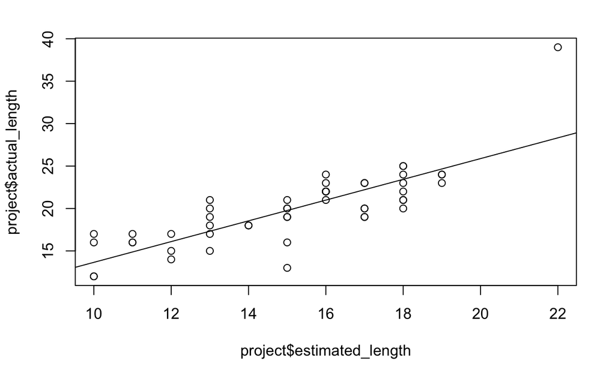

```r
abline(lin_model)
```

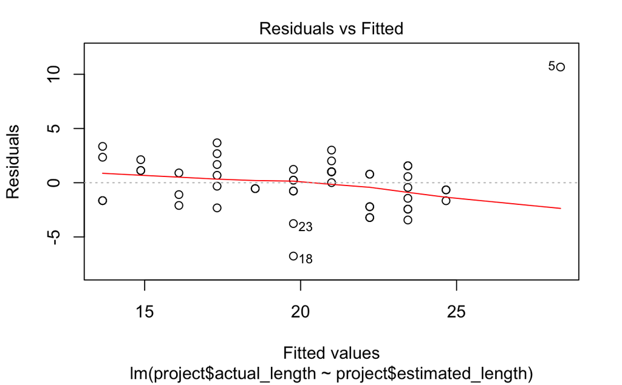

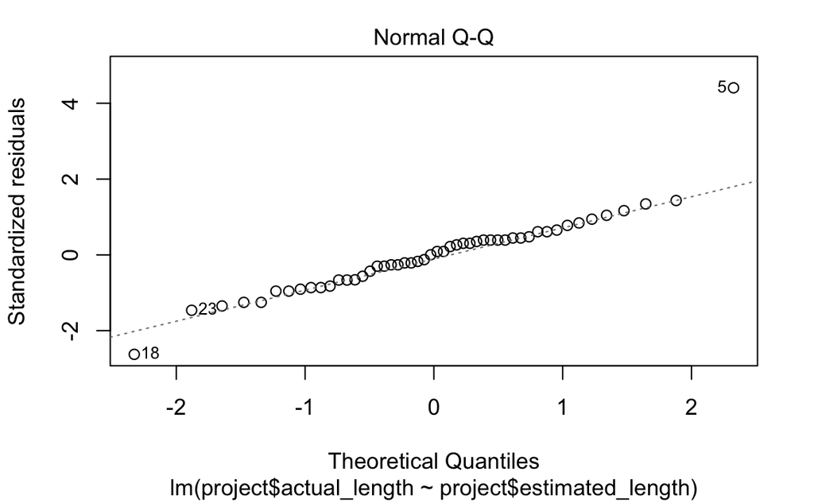

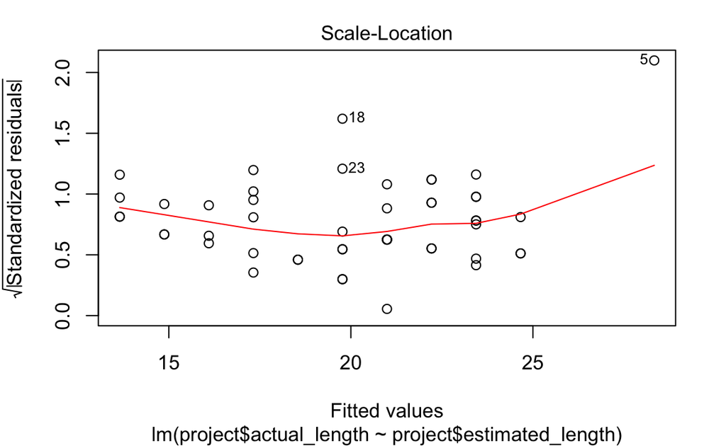

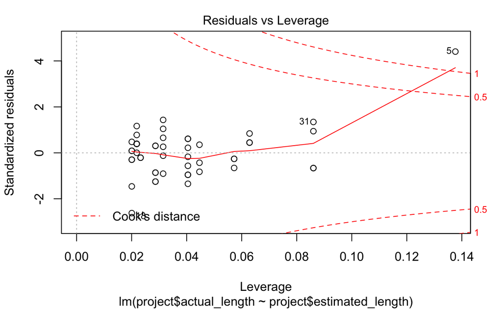

```r
plot(lin_model)
```

```r
lin_model
```

```
Call:
lm(formula = project$actual_length ~ project$estimated_length,
    data = project)

Coefficients:
             (Intercept)  project$estimated_length
                   1.416                     1.223
```

```r
summary(lin_model)
```

```
Call:
lm(formula = project$actual_length ~ project$estimated_length,
    data = project)

Residuals:
    Min      1Q  Median      3Q     Max
-6.7687 -1.6513  0.1195  1.1252 10.6669

Coefficients:
                         Estimate Std. Error t value Pr(>|t|)
(Intercept)                1.4164     2.0069   0.706    0.484
project$estimated_length   1.2235     0.1303   9.389 1.91e-12 ***
---
Signif. codes:  0 ‘***’ 0.001 ‘**’ 0.01 ‘*’ 0.05 ‘.’ 0.1 ‘ ’ 1

Residual standard error: 2.606 on 48 degrees of freedom
Multiple R-squared:  0.6475,    Adjusted R-squared:  0.6401
F-statistic: 88.16 on 1 and 48 DF,  p-value: 1.911e-12
```

Obtain the intercept and regression coefficient of variable estimated_length for a simple linear model fitted to data omitting one of your non-influential outlier points.

```r
project_less_non_inf <- subset(project, X1 != 18)

lin_model_less_ni <- lm(project_less_non_inf$actual_length ~ project_less_non_inf$estimated_length,
                data = project_less_non_inf)
lin_model_less_ni
```

```
Call:
lm(formula = project_less_non_inf$actual_length ~ project_less_non_inf$estimated_length,
    data = project_less_non_inf)

Coefficients:
                          (Intercept)
                                1.591
project_less_non_inf$estimated_length
                                1.221
```

How different are the intercept and coefficient from those obtained above by fitting the full data set? Does this support classifying the omitted point as non-influential?

All data: coef_intercept = 1.416 coef = 1.223

W/o non-influential coef_intercept = 1.591 coef = 1.221

Plot the data points, this regression line and the regression line for the full data set. How different are the lines?

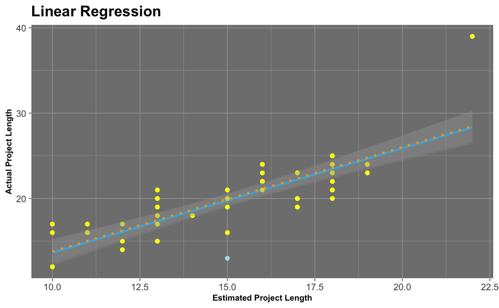

```r
ggplot() +
  geom_point(data = project, aes(x = estimated_length, y = actual_length),
                                 colour = "powderblue") +
  geom_smooth(data = project,
              aes(x = estimated_length, y = actual_length),
                  method = "lm", colour = "deepskyblue1") +
  geom_point(data = project_less_non_inf, aes(x = estimated_length, y = actual_length),
                                 colour = "yellow1") +
  geom_smooth(data = project_less_non_inf,
              aes(x = estimated_length, y = actual_length),
                  method = "lm", colour = "orange", linetype = "dotted") +
  labs(
    x = "Estimated Project Length",
    y = "Actual Project Length",
    title = "Linear Regression"
  ) +
  my_theme()
```

Repeat the procedure above, but this time omitting one of your influential outliers.

```r
project_less_inf <- subset(project, X1 != 5)

lin_model_inf <- lm(project_less_inf$actual_length ~ project_less_inf$estimated_length,
                data = project_less_inf)
lin_model_inf
```

```
Call:
lm(formula = project_less_inf$actual_length ~ project_less_inf$estimated_length,
    data = project_less_inf)

Coefficients:
                      (Intercept)  project_less_inf$estimated_length
                            4.381                              1.011
```

How different are the intercept and coefficient from those obtained above by fitting the full data set? Does this support classifying the omitted point as non-influential?

All data: coef_intercept = 1.416 coef = 1.223

W/o influential coef_intercept = 4.381 coef = 1.011

[figure not shown]

```r
ggplot() +
  geom_point(data = project,
             aes(x = estimated_length, y = actual_length),
             colour = "powderblue") +
  geom_smooth(data = project,
              aes(x = estimated_length, y = actual_length, colour ="deepskyblue1"),
              method = "lm") +
  geom_point(data = project_less_inf,
             aes(x = estimated_length, y = actual_length),
             colour = "yellow1") +
  geom_smooth(data = project_less_inf,
              aes(x = estimated_length, y = actual_length, colour = "orange"),
              method = "lm",
              linetype = "dotted",
              fullrange = T) +
   scale_colour_manual(name="legend", values= c("deepskyblue1", "orange"),
                       labels = c("lm fit", "rlm fit")) +
  labs(
    x = "Estimated Project Length",
    y = "Actual Project Length",
    title = "Linear Regression"
  ) +
  my_theme()
```

Return to your fitted model for the complete data set and examine and comment upon the Residuals vs Fitted, Normal Q-Q and Scale-Location diagnostic plots. Are the regression assumptions reasonably satisfied?

There are various techniques to perform what is known as ‘robust regression’ on a dataset. Robust methods are less affected by the presence of outliers. See the rlm() function (‘robust linear model’) in the MASS package and this blog post.

```r
library(MASS)
```

```r
fm.rlm <- rlm(project$actual_length ~ project$estimated_length, data = project)
plot(project$actual_length ~ project$estimated_length, data = project)
abline(lin_model, col = "blue")
```

[figure not shown]

```r
abline(fm.rlm, col="red")
legend("topright", inset=0.05, bty="n",
       legend = c("lm fit to original data", "rlm fit"),
       lty = c(1, 1),      # 1 = "solid" ; 2 = "dashed"
       col = c("black", "black", "red", "blue")
       )
```

with ggplot

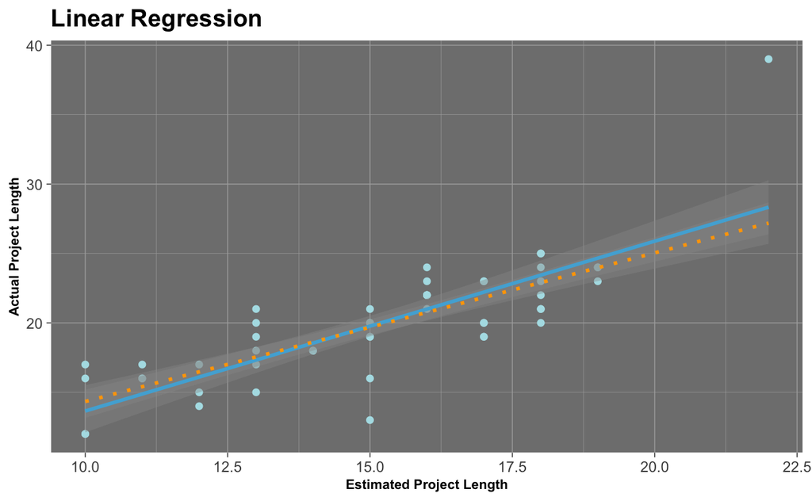

```r
ggplot(project) +
  aes(x = estimated_length, y = actual_length) +
  geom_point(colour = "powderblue") +
  geom_smooth(method = "lm", colour = "deepskyblue1") +
  geom_smooth(method = "rlm", colour = "orange", linetype = "dotted") +
  labs(
    x = "Estimated Project Length",
    y = "Actual Project Length",
    title = "Linear Regression"
  ) +
  my_theme()
```